# Attempt at Categorizing UFO Sightings

#### Matthew Peach

I'm wondering if a model could categorize the shape of a reported UFO. I've come a long way since working on this dataset in an earlier project. I now know how to encode categorical data and use flair to transform text into data that is more usable. So, I'm really excited to try this out.

```python
import numpy as np
import pandas as pd
import matplotlib as mpl
import matplotlib.pyplot as plt
```

## Loading and examining the dataset

```python
df = pd.read_csv("nuforc_reports.csv")
df.info()
```

```
<class 'pandas.core.frame.DataFrame'>
RangeIndex: 138018 entries, 0 to 138017
Data columns (total 13 columns):
 #   Column          Non-Null Count   Dtype
---  ------          --------------   -----
 0   summary         137948 non-null  object
 1   country         137794 non-null  object
 2   city            137607 non-null  object
 3   state           128648 non-null  object
 4   date_time       135372 non-null  object
 5   shape           131786 non-null  object
 6   duration        131240 non-null  object
 7   stats           138018 non-null  object
 8   report_link     138018 non-null  object
 9   text            137984 non-null  object
 10  posted          135372 non-null  object
 11  city_latitude   113060 non-null  float64
 12  city_longitude  113060 non-null  float64
dtypes: float64(2), object(11)
memory usage: 13.7+ MB
```

I'd like to use "shape" as the target, but there's a few things I don't like about this data as-is:

- "other" is the 5th most reported shape.
- "fireball" could easily describe a meteor.
- A few are the shapes are very infrequently reported.

```python
df["shape"].value_counts()
```

```
shape
light        27948
circle       14599
triangle     12366
fireball      9583
other         9479
unknown       9349
sphere        8969
disk          8162
oval          5978
formation     4597
changing      3433
cigar         3397
rectangle     2378
flash         2375
cylinder      2176
diamond       1989
chevron       1581
egg           1193
teardrop      1181
cone           550
cross          447
star            34
delta           22
Name: count, dtype: int64
```

#### What is the difference between "text" and "summary"?

"summary" is a summary of "text" - the raw texts can be quite long (as shown below).

```python
print(df["summary"][100])
```

```
Very unusual morning and lighting.
```

```python
print(df["text"][100])
```

```
Very unusual morning and lighting

These unknown crafts two in total were over this nuclear power plant I live buy and how the lights of these two crafts would go in and out be in one area then when the lights were out and came back on they would be in a different location with in a second just they way these lights were moving in al…
```

```python
print(df["summary"][500])
```

```
Grey Spheres flying fast, and low above city, appearing out of nowhere and disappearing into nothing.
```

```python
print(df["text"][500])
```

```
Grey Spheres flying fast, and low above city, appearing out of nowhere and disappearing into nothing.

My fiancé and I stepped outside our business for a cigarette. We run an exotic animal rescue and actually live in the back, there is an apartment. We were talking and I was looking at the sky, the next I thing I see is 5 grey, metallic looking spheres flying very low above our business and off into …
```

## Data cleaning and transformation

### Cutting down the dataframe to only features that I want

```python
df.info()
```

```
<class 'pandas.core.frame.DataFrame'>
RangeIndex: 138018 entries, 0 to 138017
Data columns (total 13 columns):
 #   Column          Non-Null Count   Dtype
---  ------          --------------   -----
 0   summary         137948 non-null  object
 1   country         137794 non-null  object
 2   city            137607 non-null  object
 3   state           128648 non-null  object
 4   date_time       135372 non-null  object
 5   shape           131786 non-null  object
 6   duration        131240 non-null  object
 7   stats           138018 non-null  object
 8   report_link     138018 non-null  object
 9   text            137984 non-null  object
 10  posted          135372 non-null  object
 11  city_latitude   113060 non-null  float64
 12  city_longitude  113060 non-null  float64
dtypes: float64(2), object(11)
memory usage: 13.7+ MB
```

#### Dropping country because it is highly unstructured.

```python
print(df["country"].value_counts())
df = df.drop("country", axis = 1)
```

```
country
USA                           123100
Canada                          5581
United Kingdom                  3008
Australia                        861
India                            421
                               ...
Sweden/Denmark                     1
no                                 1
mid-Atlantic Ocean                 1
Atlantic Ocean/Puerto Rico         1
turkey                             1
Name: count, Length: 431, dtype: int64
```

#### Dropping stats because it is just a reiteration of the other features.

(This feature might have been useful if the string was comma separated, but there are spaces all over it. Parsing it would be a bit annoying.)

```python
print(df["stats"][5])
df = df.drop("stats", axis = 1)
```

```
Occurred : 6/18/2021 01:20  (Entered as : 06/18/2021 1:20) Reported: 6/18/2021 2:50:48 AM 02:50 Posted: 7/31/2021 Location: Oakland, CA Shape: Circle Duration: 7 min
```

#### Dropping city because we already have the latitude and longitude anyway. Also, the entries don't follow a consistent format.

```python
print(df["city"].value_counts())
df = df.drop("city", axis = 1)
```

```
city
New York                             861
Phoenix                              780
Seattle                              773
Las Vegas                            661
Portland                             648
                                    ...
Alma KOA                               1
Bee Cave                               1
Cucuta (Colombia)                      1
Manchester (Salford) (UK/England)      1
Somerton                               1
Name: count, Length: 23245, dtype: int64
```

#### Dropping duration because it is highly unstructured.

```python
df = df.drop(["duration"], axis = 1)
```

#### Simple datatype conversions

```python
df["date_time"] = pd.to_datetime(df["date_time"])
df["posted"] = pd.to_datetime(df["posted"])
```

#### Dropping rows with null values

```python
df = df.dropna()
df = df.reset_index(drop = True)
```

### Dropping sightings not in the continental US

From the last project, I know that the reports in this dataset are concentrated in the continental United States. I'm going to treat the reports outside of the US kind of like outliers and drop them. A plot below will show what the data locations look like right now.

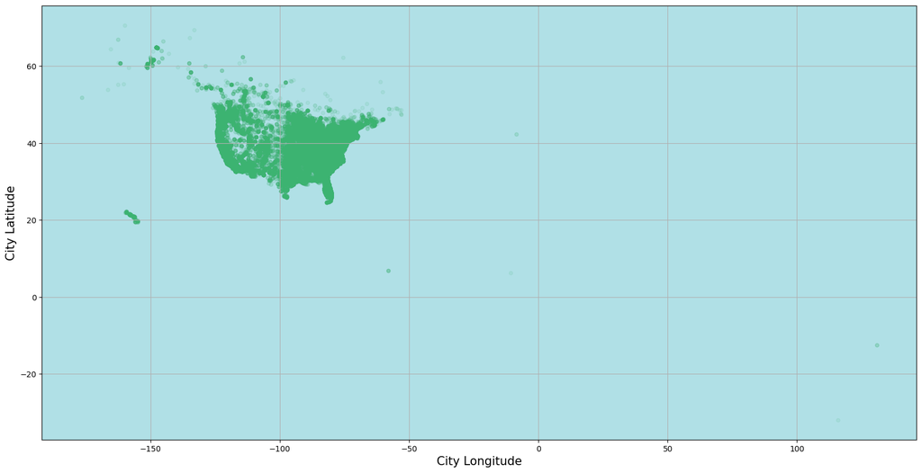

```python
# (I tried to make it look part of a globe)

ax = df.plot(kind = "scatter", x = "city_longitude", y = "city_latitude", c = "mediumseagreen",
             alpha = 0.1, figsize = [20,10])
ax.set_facecolor("powderblue")
ax.grid(True)
ax.set_xlabel("City Longitude", fontsize = 15)
ax.set_ylabel("City Latitude", fontsize = 15)
```

```python
# Drop reports that are too far west
df.drop(df[df["city_longitude"] < -126.00].index, inplace = True)

# Too far east
df.drop(df[df["city_longitude"] > -66].index, inplace = True)

# Too far south
df.drop(df[df["city_latitude"] < 23].index, inplace = True)

# Too far north
df.drop(df[df["city_latitude"] > 50].index, inplace = True)
```

### Visualization of the new dataframe

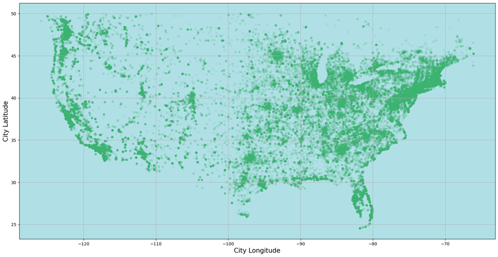

```python
ax = df.plot(kind = "scatter", x = "city_longitude", y = "city_latitude", c = "mediumseagreen",
             alpha = 0.1, figsize = [20,10])
ax.set_facecolor("powderblue")
ax.grid(True)
ax.set_xlabel("City Longitude", fontsize = 15)
ax.set_ylabel("City Latitude", fontsize = 15)
```

```python
df = df.reset_index(drop = True)
df.info()
```

```
<class 'pandas.core.frame.DataFrame'>
RangeIndex: 104100 entries, 0 to 104099
Data columns (total 9 columns):
 #   Column          Non-Null Count   Dtype
---  ------          --------------   -----
 0   summary         104100 non-null  object
 1   state           104100 non-null  object
 2   date_time       104100 non-null  datetime64[ns]
 3   shape           104100 non-null  object
 4   report_link     104100 non-null  object
 5   text            104100 non-null  object
 6   posted          104100 non-null  datetime64[ns]
 7   city_latitude   104100 non-null  float64
 8   city_longitude  104100 non-null  float64
dtypes: datetime64[ns](2), float64(2), object(5)
memory usage: 7.1+ MB
```

## Transformation with flair

#### (screenshot to avoid compatability issues)

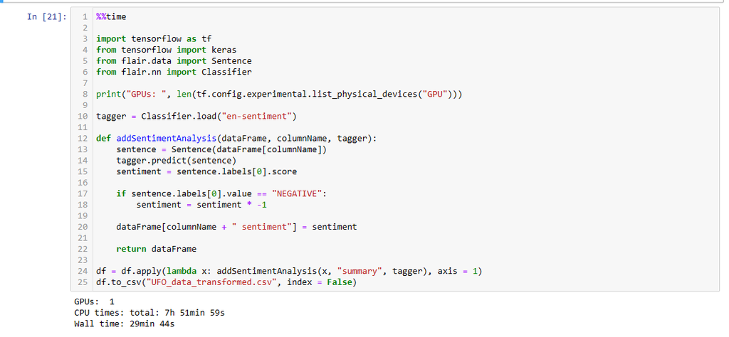

### Loading transformed data from csv file

```python
df = pd.read_csv("UFO_data_transformed.csv")
df["date_time"] = pd.to_datetime(df["date_time"])
df["posted"] = pd.to_datetime(df["posted"])
df.info()
```

```
<class 'pandas.core.frame.DataFrame'>
RangeIndex: 104100 entries, 0 to 104099
Data columns (total 10 columns):
 #   Column             Non-Null Count   Dtype
---  ------             --------------   -----
 0   summary            104100 non-null  object
 1   state              104100 non-null  object
 2   date_time          104100 non-null  datetime64[ns]
 3   shape              104100 non-null  object
 4   report_link        104100 non-null  object
 5   text               104100 non-null  object
 6   posted             104100 non-null  datetime64[ns]
 7   city_latitude      104100 non-null  float64
 8   city_longitude     104100 non-null  float64
 9   summary sentiment  104100 non-null  float64
dtypes: datetime64[ns](2), float64(3), object(5)
memory usage: 7.9+ MB
```

### Dropping report_link

I don't see this being useful for training or for looking at afterwards, since I'm keeping summary and text

```python
df = df.drop("report_link", axis = 1)

df.info()
```

```
<class 'pandas.core.frame.DataFrame'>
RangeIndex: 104100 entries, 0 to 104099
Data columns (total 9 columns):
 #   Column             Non-Null Count   Dtype
---  ------             --------------   -----
 0   summary            104100 non-null  object
 1   state              104100 non-null  object
 2   date_time          104100 non-null  datetime64[ns]
 3   shape              104100 non-null  object
 4   text               104100 non-null  object
 5   posted             104100 non-null  datetime64[ns]
 6   city_latitude      104100 non-null  float64
 7   city_longitude     104100 non-null  float64
 8   summary sentiment  104100 non-null  float64
dtypes: datetime64[ns](2), float64(3), object(4)
memory usage: 7.1+ MB
```

## Average sentiments of sightings over time

```python
# Converting date_time to only have month and year

df_YM = df.copy()
df_YM["date_time"] = df_YM["date_time"].dt.strftime("%Y-%m")


table = pd.pivot_table(df_YM, index = "date_time", values = "summary sentiment", aggfunc = np.mean)

dfDates = table.pivot_table("summary sentiment", index = "date_time")

# Making sure the index is actually a date
dfDates.index = pd.to_datetime(dfDates.index)

dfDates
```

| date_time | summary sentiment |
| --- | --- |
| 1969-01-01 | -0.289045 |
| 1969-02-01 | -0.979928 |
| 1969-03-01 | -0.587033 |
| 1969-04-01 | -0.989617 |
| 1969-05-01 | -0.013672 |
| ... | ... |
| 2022-02-01 | -0.374563 |
| 2022-03-01 | -0.313481 |
| 2022-04-01 | -0.507559 |
| 2022-05-01 | -0.372985 |
| 2022-06-01 | -0.314614 |

641 rows × 1 columns

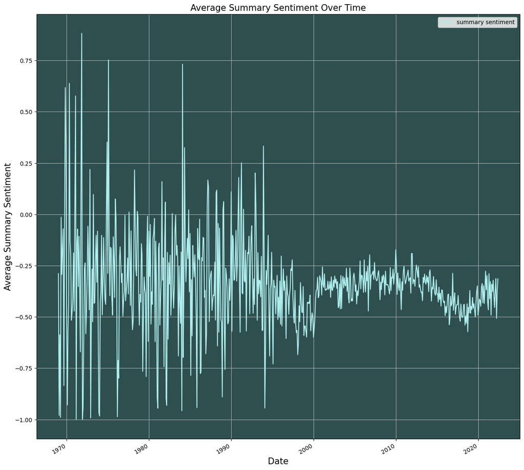

```python
fig, ax = plt.subplots(figsize = (15,15))
dfDates.plot.line(ax = ax, color = "paleturquoise")
ax.set_facecolor("darkslategrey")
ax.grid(True)
ax.set_title("Average Summary Sentiment Over Time", fontsize = 15)
ax.set_xlabel("Date", fontsize = 15)
ax.set_ylabel("Average Summary Sentiment", fontsize = 15)


# ----- Can change sighting date range here to look at different dates -----
# ax.set_xlim("2010-01", "2021-01")
#---------------------------------------------------------------------------
```

## Number of Sightings over time

The average sentiment gets more stable as time goes on. This may be because there are very few old report, resulting in many outliers. Lets see.

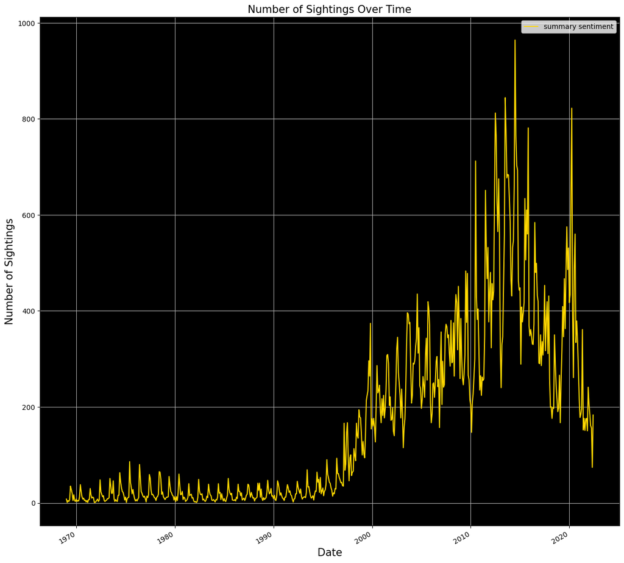

```python
table2 = pd.pivot_table(df_YM, index = "date_time", values = "summary sentiment", aggfunc = "count")
table2.index = pd.to_datetime(table2.index)

fig, ax = plt.subplots(figsize = (15,15))
table2.plot.line(ax = ax, color = "gold")
ax.set_facecolor("black")
ax.grid(True)
ax.set_title("Number of Sightings Over Time", fontsize = 15)
ax.set_xlabel("Date", fontsize = 15)
ax.set_ylabel("Number of Sightings", fontsize = 15)


# ----- Can change sighting date range here to look at different dates -----
# ax.set_xlim("2010-01", "2021-01")
#---------------------------------------------------------------------------
```

It does appear that the reported sightings rise significantly leading up to and after 2000. The pattern before the 2000s is also a bit odd; maybe there's a month pre-2000 that sightings keep falling into?

## Encoding the Classes

```python
df["shape"].value_counts()
```

```
shape
light        22391
circle       11512
triangle     10105
fireball      7876
unknown       7440
other         7375
sphere        7035
disk          5766
oval          4658
formation     3650
changing      2754
cigar         2563
flash         1902
rectangle     1888
cylinder      1698
diamond       1539
chevron       1304
teardrop       935
egg            893
cone           411
cross          366
star            24
delta           15
Name: count, dtype: int64
```

This is a bit based on opinion, but I think a lot of these shapes could be condensed into one shape. I also think they could potentially be ordered based on number of sides or edges. For example, light has 0 edges, disk/circle has one, triangle, delta have 3. I also think some shapes should just be dropped for being too rare.

Here's what I've decided to do:

#### Drop

- unknown - This is a classification task, so this is kind of useless.
- other - Not sure what this is representative of.
- cross - Too few and too different than the other shapes.
- fireball - Could easily be a meteor, but why weren't these not originally classified as "light"?
- star - Too few and is this a five-pointed shape or shaped like a star in the night sky?
- changing - Changing what? Light color, shape, direction?

**Again, these class groupings/encodings are fairly opinion-based.**

#### Class Encodings

- 0: light, flash - No associated physical shape.
- 1: circle, disk - Circular shapes.
- 2: sphere, oval, teardrop, egg - Ovoid shapes.
- 3: cigar, cylinder - Elongated ovoid shapes.
- 4: triangle, cone - Triangular shapes.
- 5: rectangle, diamond - Rectangular shapes.
- 6: formation, chevron, delta - Various in one sighting. This one is a bit strange since it doesn't really specify a shape of an individual object.

```python
df.drop(df[df["shape"] == "unknown"].index, inplace = True)
df.drop(df[df["shape"] == "other"].index, inplace = True)
df.drop(df[df["shape"] == "cross"].index, inplace = True)
df.drop(df[df["shape"] == "fireball"].index, inplace = True)
df.drop(df[df["shape"] == "star"].index, inplace = True)
df.drop(df[df["shape"] == "changing"].index, inplace = True)

df["shape"] = df["shape"].replace({
    "light": 0,
    "flash": 0,
    "circle": 1,
    "disk": 1,
    "sphere": 2,
    "oval": 2,
    "teardrop": 2,
    "egg": 2,
    "cigar": 3,
    "cylinder": 3,
    "triangle": 4,
    "cone": 4,
    "rectangle": 5,
    "diamond": 5,
    "formation": 6,
    "chevron": 6,
    "delta": 6
})
```

```python
df = df.reset_index(drop = True)
df.info()
```

```
<class 'pandas.core.frame.DataFrame'>
RangeIndex: 78265 entries, 0 to 78264
Data columns (total 9 columns):
 #   Column             Non-Null Count  Dtype
---  ------             --------------  -----
 0   summary            78265 non-null  object
 1   state              78265 non-null  object
 2   date_time          78265 non-null  datetime64[ns]
 3   shape              78265 non-null  int64
 4   text               78265 non-null  object
 5   posted             78265 non-null  datetime64[ns]
 6   city_latitude      78265 non-null  float64
 7   city_longitude     78265 non-null  float64
 8   summary sentiment  78265 non-null  float64
dtypes: datetime64[ns](2), float64(3), int64(1), object(3)
memory usage: 5.4+ MB
```

### Encoding Date

```python
def datetime64_to_DDMMYY(dataFrame, columnName):
    date = str(dataFrame[columnName])
    dateArr = date.replace(" ", "-").split("-")
    dataFrame["day"] = int(dateArr[2])
    dataFrame["month"] = int(dateArr[1])
    dataFrame["year"] = int(dateArr[0])
    return dataFrame

df = df.apply(lambda x: datetime64_to_DDMMYY(x, "date_time"), axis = 1)

df.head()
```

|  | summary | state | date_time | shape | text | posted | city_latitude | city_longitude | summary sentiment | day | month | year |
| --- | --- | --- | --- | --- | --- | --- | --- | --- | --- | --- | --- | --- |
| 0 | Long and narrow illuminated craft flying high ... | OR | 2021-05-15 22:36:00 | 3 | Long and narrow illuminated craft flying high ... | 2021-05-20 | 44.315600 | -121.517500 | -0.996040 | 15 | 5 | 2021 |
| 1 | 30+ lights in a line. | TN | 2021-05-05 22:35:00 | 0 | 30+ lights in a line. \n \nI have night vision... | 2021-05-20 | 35.146426 | -84.851657 | 0.999821 | 5 | 5 | 2021 |
| 2 | I was standing at my kitchen sink and looked u... | NY | 2020-10-16 18:25:00 | 1 | I was standing at my kitchen sink and looked u... | 2021-08-20 | 43.022500 | -74.026300 | -0.999267 | 16 | 10 | 2020 |
| 3 | Multiple slow moving craft seen all over the s... | PA | 2021-06-18 01:00:00 | 1 | Multiple slow moving craft seen all over the s... | 2021-07-31 | 40.014600 | -75.713600 | -0.999929 | 18 | 6 | 2021 |
| 4 | 1:20 am Huge Orange Circular Craft over the SE... | CA | 2021-06-18 01:20:00 | 1 | 1:20 am Huge Orange Circular Craft over the SE... | 2021-07-31 | 37.798475 | -122.231639 | 0.991366 | 18 | 6 | 2021 |

## Data Splitting

The following splits are stratified to keep similar compositions of each class

```python
from sklearn.model_selection import train_test_split

features = ["city_latitude", "city_longitude", "summary sentiment", "day", "month", "year"]
target = ["shape"]


# train = 60%, test = 20%, valid = 20%


X_train, X_test, y_train, y_test = train_test_split(df[features], df[target], test_size = 0.2,
                                                    random_state = 93, stratify = df[target])


X_train, X_valid, y_train, y_valid = train_test_split(X_train, y_train, test_size = 0.25,
                                                      random_state = 93, stratify = y_train)
```

```python
print("Targetss in test data:\n", y_train.value_counts())
print("\nTargets in validation data:\n", y_valid.value_counts())
print("\nTargets in test data: \n", y_test.value_counts())
```

```
Targetss in test data:
 shape
0        14576
1        10366
2         8113
4         6310
6         2981
3         2557
5         2056
Name: count, dtype: int64

Targets in validation data:
 shape
0        4858
1        3456
2        2704
4        2103
6         994
3         852
5         686
Name: count, dtype: int64

Targets in test data:
 shape
0        4859
1        3456
2        2704
4        2103
6         994
3         852
5         685
Name: count, dtype: int64
```

## Random Forest

```python
%%time

from sklearn.ensemble import RandomForestClassifier
from sklearn.metrics import classification_report

# Default n_estimators = 100
randomForest = RandomForestClassifier(random_state = 93)
randomForest.fit(X_train, y_train.values.ravel())
y_pred = randomForest.predict(X_valid)
print(classification_report(y_pred, y_valid))
```

```
              precision    recall  f1-score   support

           0       0.65      0.33      0.44      9505
           1       0.25      0.26      0.25      3311
           2       0.11      0.19      0.14      1606
           3       0.02      0.23      0.04        88
           4       0.09      0.21      0.13       934
           5       0.01      0.11      0.02        73
           6       0.03      0.23      0.05       136

    accuracy                           0.29     15653
   macro avg       0.17      0.22      0.15     15653
weighted avg       0.46      0.29      0.34     15653

CPU times: total: 13.8 s
Wall time: 13.8 s
```

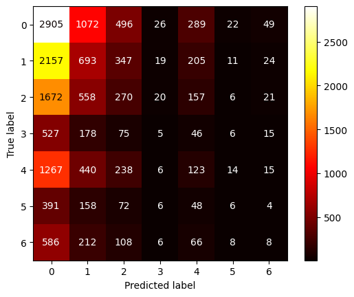

```python
from sklearn.metrics import confusion_matrix
from sklearn.metrics import ConfusionMatrixDisplay

confusionMatrix = confusion_matrix(y_test, y_pred)
cm_display = ConfusionMatrixDisplay(confusion_matrix = confusionMatrix)
cm_display.plot(cmap = "hot")
plt.show()
```

## Extra-Trees

```python
%%time
from sklearn.ensemble import ExtraTreesClassifier

extraTrees = ExtraTreesClassifier(random_state = 93)
extraTrees.fit(X_train, y_train.values.ravel())
y_pred = extraTrees.predict(X_valid)
print(classification_report(y_pred, y_valid))
```

```
              precision    recall  f1-score   support

           0       0.59      0.33      0.43      8707
           1       0.25      0.26      0.25      3415
           2       0.14      0.20      0.16      1854
           3       0.05      0.21      0.08       195
           4       0.10      0.19      0.13      1088
           5       0.01      0.07      0.02       129
           6       0.05      0.20      0.08       265

    accuracy                           0.28     15653
   macro avg       0.17      0.21      0.16     15653
weighted avg       0.41      0.28      0.32     15653

CPU times: total: 6.7 s
Wall time: 6.71 s
```

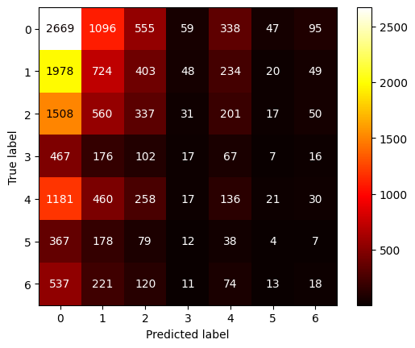

```python
confusionMatrix = confusion_matrix(y_test, y_pred)
cm_display = ConfusionMatrixDisplay(confusion_matrix = confusionMatrix)
cm_display.plot(cmap = "hot")
plt.show()
```

## SVM (RBF Kernel)

This took quite a while to train, even trying different values for C, the model would not give a classification other than 0 (lights) to any instance.

```python
%%time
from sklearn.svm import SVC

svm = SVC(random_state = 93)
svm.fit(X_train, y_train.values.ravel())
y_pred = svm.predict(X_valid)
print(classification_report(y_pred, y_valid))
```

```
              precision    recall  f1-score   support

           0       1.00      0.31      0.47     15653
           1       0.00      0.00      0.00         0
           2       0.00      0.00      0.00         0
           3       0.00      0.00      0.00         0
           4       0.00      0.00      0.00         0
           5       0.00      0.00      0.00         0
           6       0.00      0.00      0.00         0

    accuracy                           0.31     15653
   macro avg       0.14      0.04      0.07     15653
weighted avg       1.00      0.31      0.47     15653

CPU times: total: 3min 50s
Wall time: 3min 50s
```

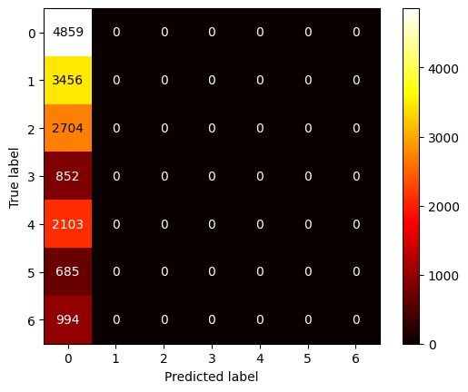

```python
confusionMatrix = confusion_matrix(y_test, y_pred)
cm_display = ConfusionMatrixDisplay(confusion_matrix = confusionMatrix)
cm_display.plot(cmap = "hot")
plt.show()
```

## Voting Classifier

I'm leaving out the SVM here because it didn't work out.

This time I'm using soft voting instead of hard voting since I don't think hard voting with only two models makes sense - wouldn't it result in a tie sometimes? From what I understand, soft voting can weigh the votes differently based on confidence.

```python
%%time
from sklearn.ensemble import VotingClassifier

randomForestVoter = RandomForestClassifier(random_state = 93)
extraTreesVoter = ExtraTreesClassifier(random_state = 93)

voting_clf = VotingClassifier(
    estimators = [("Random Forest", randomForestVoter), ("Extra Trees", extraTreesVoter)],
    voting = "soft"
)

voting_clf.fit(X_train, y_train.values.ravel())
```

```
CPU times: total: 19.9 s
Wall time: 19.9 s
```

```
VotingClassifier(estimators=[('Random Forest',
                              RandomForestClassifier(random_state=93)),
                             ('Extra Trees',
                              ExtraTreesClassifier(random_state=93))],
                 voting='soft')
```

```python
%%time

y_pred = voting_clf.predict(X_valid)
print(classification_report(y_pred, y_valid))
```

```
              precision    recall  f1-score   support

           0       0.64      0.33      0.44      9435
           1       0.25      0.26      0.25      3309
           2       0.12      0.20      0.15      1588
           3       0.03      0.23      0.06       121
           4       0.10      0.22      0.13       943
           5       0.01      0.09      0.02        88
           6       0.04      0.24      0.07       169

    accuracy                           0.29     15653
   macro avg       0.17      0.22      0.16     15653
weighted avg       0.46      0.29      0.34     15653

CPU times: total: 1.19 s
Wall time: 1.19 s
```

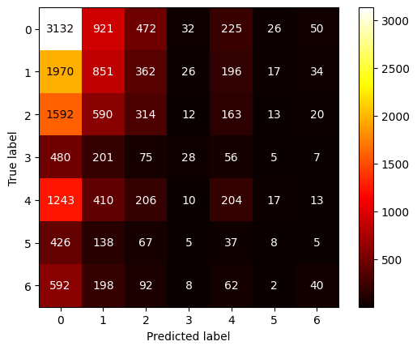

```python
confusionMatrix = confusion_matrix(y_valid, y_pred)
cm_display = ConfusionMatrixDisplay(confusion_matrix = confusionMatrix)
cm_display.plot(cmap = "hot")
plt.show()
```

## Using the Test Data

```python
%%time
from sklearn.metrics import accuracy_score

for clf in (randomForest, extraTrees, svm, voting_clf):
    y_pred = clf.predict(X_test)
    print(clf.__class__.__name__, accuracy_score(y_test, y_pred))
```

```
RandomForestClassifier 0.2971315402798186
ExtraTreesClassifier 0.29106241615025874
SVC 0.31041972784769695
VotingClassifier 0.29860090717434357
CPU times: total: 1min 17s
Wall time: 1min 17s
```

## Data source

https://data.world/timothyrenner/ufo-sightings